# 第三章 总体均数的估计与假设检验

x2yline

2017年10月18日

## 知识清单：

- t分布（t-distribution）
- 自由度（degree of freedom，df）
- 单样本t检验（one sample/group t-test）
- 配对样本t检验（paired/matched t-test）
- 两样本t检验（two-sample/group t-test）
- 正态性检验（normality test）
- 方差齐性检验（homogeneity of variance test）
- 变量变换效果展示

## 1. t分布(不同自由度）

```r
x <- seq(-4, 4, length=200)
df <- c(3, 8, 16, 61)
require(plyr)
```

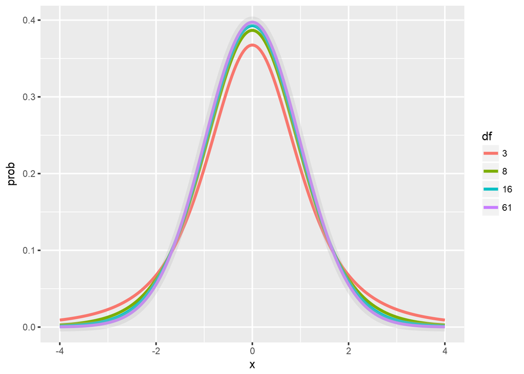

```r
get.pt <- function(x, df) {
    prob <- dt(x, df)
    dd <- data.frame(x=x, df=factor(df), prob=prob)
    return(dd)
}
pt.df <- mdply(data.frame(x= rep(x, length(df)), df=rep(df, each=length(x))), get.pt)
require(ggplot2)
ggplot(pt.df, aes(x, prob))+geom_line(aes(group=df, color=df), lwd=1)+geom_line(data=data.frame(x=x, prob=dnorm(x)), alpha=0.3, lwd=3, color="gray")
```

## 2. 单样本t检验（使用教材光盘血红蛋白数据: 例03-05.sav）

**前提条件：取自正态分布的小样本（<=60， 偏态用秩和检验)；或者取自任意分布的大样本（>60）**

```r
# install.packages("memisc")
library(memisc)
hb_df <- data.frame(as.data.set(
  spss.system.file(
    'E:\\医学统计学（第4版）\\各章例题SPSS数据文件\\例03-05.sav')))
t.test(hb_df$hb, mu=140)
```

```
##
##  One Sample t-test
##
## data:  hb_df$hb
## t = -2.005, df = 35, p-value = 0.05274
## alternative hypothesis: true mean is not equal to 140
## 95 percent confidence interval:
##  108.8621 140.1934
## sample estimates:
## mean of x
##  124.5278
```

除此之外，还可以直接计算出t值后，使用pt函数计算p值

```r
t.value <- abs((mean(hb_df$hb) - 140) /
                 sd(hb_df$hb) * sqrt(nrow(hb_df)))
p.value <- pt(t.value,
              df=nrow(hb_df)-1,
              lower.tail=FALSE)*2
```

可视化：

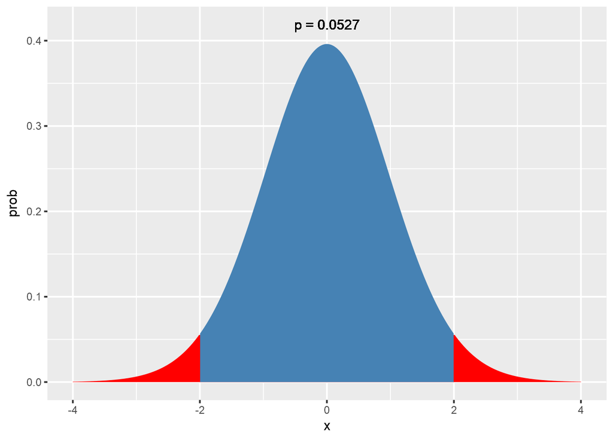

```r
x=seq(-4, 4, length=500)
d <- data.frame(x=x,
                prob=dt(x, df=length(hb_df$hb)-1))
require(ggplot2)
ggplot(d, aes(x, prob, fill=((x>-t.value & x<t.value))))+
  geom_area()+
  scale_fill_manual(values=c("TRUE"="steelblue", "FALSE"="red"))+
  theme(legend.position="none")+
  geom_text(aes(0, dnorm(0)+0.02), label=paste("p = ", round(p.value, 4), sep=""))
```

## 3. 配对样本t检验（paired/matched t-test）教材光盘数据：例03-06.sav

**前提条件：配对设计（同质对子接受两种不同处理；同一样品接受不同处理；同一对象接受处理前后）**

- 方法 1：

```r
# install.packages("memisc")
library(memisc)
paired_df <- data.frame(as.data.set(
  spss.system.file(
    'E:\\医学统计学（第4版）\\各章例题SPSS数据文件\\例03-06.sav')))
t.test(paired_df$x1, paired_df$x2, paired=TRUE)
```

```
##
##  Paired t-test
##
## data:  paired_df$x1 and paired_df$x2
## t = -1.0264, df = 9, p-value = 0.3315
## alternative hypothesis: true difference in means is not equal to 0
## 95 percent confidence interval:
##  -33.07524  12.42924
## sample estimates:
## mean of the differences
##                 -10.323
```

- 方法 2：

```r
d <- (paired_df$x1-paired_df$x2)
t.value <- abs(mean(d)/sd(d)*sqrt(length(d)))
p.value <- pt(t.value, df=length(d)-1, lower.tail=FALSE)*2
```

## 4. 两样本t检验（成组t检验Two Sample t-test）教材光盘数据：例03-06.sav[03-07数据文件发生中文错误坏，用03-06代替]

**前提条件：小样本，需要方差齐性和来自正态总体（方差不齐需用近似t检验）；或者大样本（>60）**

- 方法 1：

```r
# install.packages("memisc")
library(memisc)
group_df <- data.frame(as.data.set(
  spss.system.file(
    'E:\\医学统计学（第4版）\\各章例题SPSS数据文件\\例03-06.sav')))
group_df <- data.frame(x=c(group_df$x1, group_df$x2),
                       group=rep(c("阿卡波糖胶囊", "拜唐苹胶囊"),
                                 each=length(group_df$x1)))
t.test(group_df$x[group_df$group=="阿卡波糖胶囊"],
       group_df$x[group_df$group=="拜唐苹胶囊"], paired=FALSE)
```

```
##
##  Welch Two Sample t-test
##
## data:  group_df$x[group_df$group == "阿卡波糖胶囊"] and group_df$x[group_df$group == "拜唐苹胶囊"]
## t = -1.0269, df = 9.0006, p-value = 0.3313
## alternative hypothesis: true difference in means is not equal to 0
## 95 percent confidence interval:
##  -33.0638  12.4178
## sample estimates:
## mean of x mean of y
##   -9.5278    0.7952
```

- 方法 2：

```r
library(plyr)
group_dd <- ddply(group_df, .(group),
                  function(x) data.frame(SD=sd(x$x), n=length(x$x), mean=mean(x$x)))
diff_se <- sqrt(sum(group_dd$SD^2*(group_dd$n-1))/
                  sum(group_dd$n-1)*sum(1/group_dd$n))
t.value <- abs((group_dd$mean[1]-group_dd$mean[2])/
                 diff_se)
p.value <- pt(t.value, df=sum(group_dd$n)-2,
              lower.tail=FALSE)*2
```

## 5. 正态性检验

**一般不必要使用，多用于采用正态分布法制定参考值范围时**

- [正态性检验之qq plot与pp plot原理介绍](http://www.jianshu.com/p/4c5a6dc44dda)
- [正态性检验之矩法（method of moment）计算偏度skewness和峰度kurtosis](http://note.youdao.com/noteshare?id=c76111a616412eca7ebbabc51023ecbe&sub=1CC99161D36A4A1AAA0E6E06F5B169D7)

## 6. 方差齐性的F检验，教材光盘数据：例03-06.sav

**F检验理论上需要满足资料服从正态分布，进行方差齐性检验更多采用另一种不依赖总体分布形式的Lecene检验** > 进行f和t一样，r语言有df，pf，qf，rf和var.test等函数

- 方法 1：

```r
# install.packages("memisc")
library(memisc)
group_df <- data.frame(as.data.set(
  spss.system.file(
    'E:\\医学统计学（第4版）\\各章例题SPSS数据文件\\例03-06.sav')))
group_df <- data.frame(x=c(group_df$x1, group_df$x2),
                       group=rep(c("阿卡波糖胶囊", "拜唐苹胶囊"),
                                 each=length(group_df$x1)))
var.test(group_df$x[group_df$group=="阿卡波糖胶囊"], group_df$x[group_df$group=="拜唐苹胶囊"])
```

```
##
##  F test to compare two variances
##
## data:  group_df$x[group_df$group == "阿卡波糖胶囊"] and group_df$x[group_df$group == "拜唐苹胶囊"]
## F = 29732, num df = 9, denom df = 9, p-value < 2.2e-16
## alternative hypothesis: true ratio of variances is not equal to 1
## 95 percent confidence interval:
##    7384.905 119699.186
## sample estimates:
## ratio of variances
##           29731.58
```

- 方法 2：

```r
f.val <- sd(group_df$x[group_df$group=="阿卡波糖胶囊"])^2/
  var(group_df$x[group_df$group == "拜唐苹胶囊"])
p.val <- pf(f.val, df1=19, df2=19, lower.tail=FALSE)*2
```

## 7. 变量变换

对数变换：数据效应为相乘，变异系数接近常数

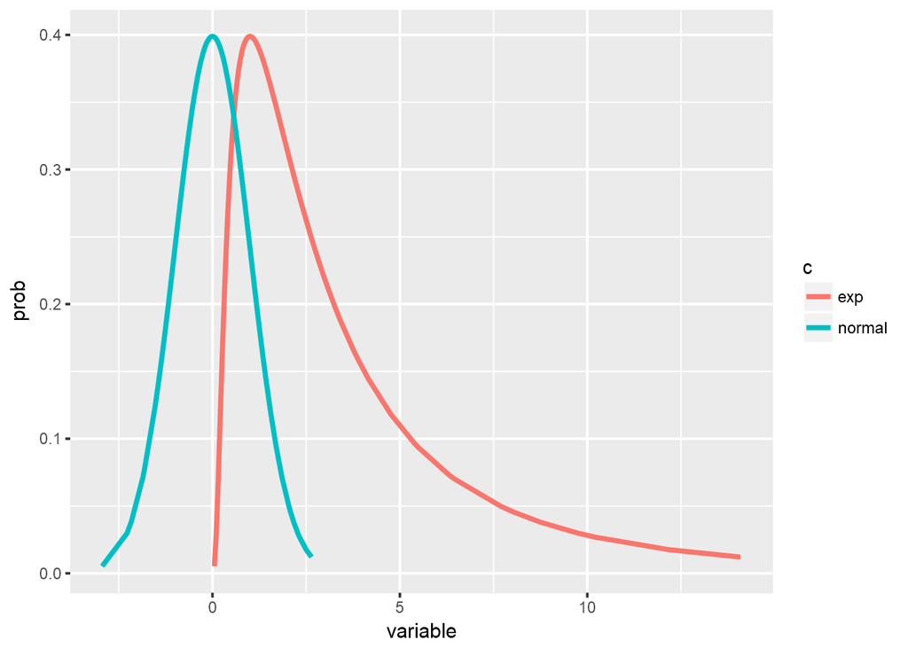

```r
library(ggplot2)
b <- rnorm(100)
prob <- dnorm(b)
a <- exp(b)
data <- data.frame(variable=c(a, b),
                   c= rep(c("exp", "normal"), each=length(a)),
                   prob=c(prob, prob))
ggplot(data=data, aes(variable, prob, color=c))+geom_line(lwd=1)
```

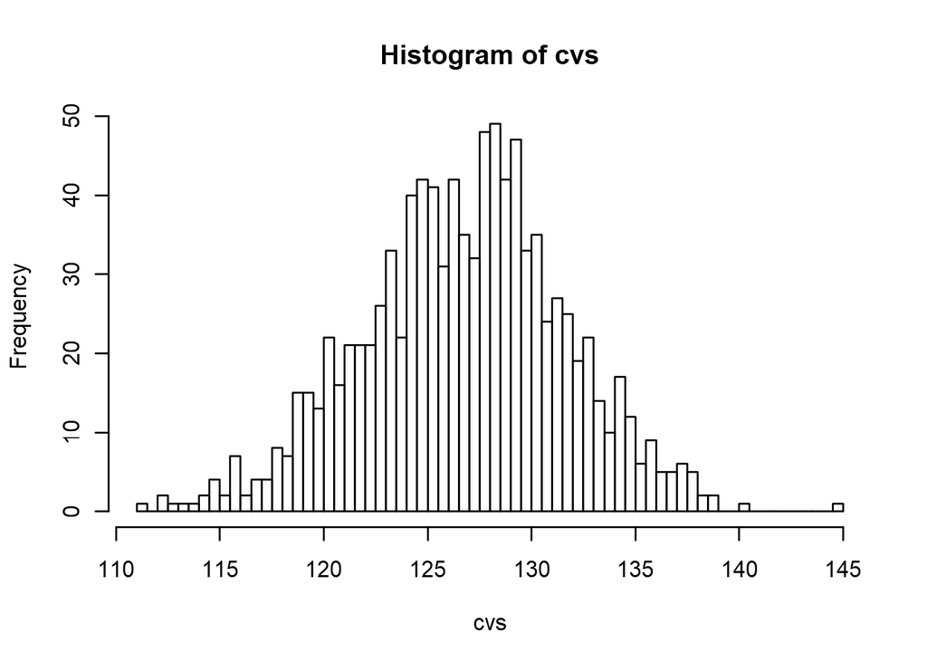

```r
cvs <- c()
for (i in 1:1000) {cvs <- c(cvs, (raster::cv(sample(a, 79))))}
hist(cvs, breaks=100)
```

- 平方根变换：适用于Posson分布资料，方差与均数近似相等，轻度偏态（如发病的地域或时间分布）
- 反正弦变换：率或百分比的数据
- 倒数变换：两端波动大的数据

## 参考：

[1] 孙振球 徐勇勇. 医学统计学【第四版】  
[2] https://guangchuangyu.github.io/statistics_notes/section-4.html#section-4.1